# R Notebook

# Assignment1 2017250104 윤지호

나의 원래 주제는 뇌발달 단계별 중요 유전자와 발달장애 유전자의 관계를 짓고, 발달 과정에 존재하는 치명적인 역할을 하는 유전자들을 mapping하려고 하였으나, 발달장애 유전자가 뇌발달의 가장 많이 발현되는 유전자가 아님을 우선 확인하여, 주제를 조금 바꾸어서 진행하였다. 결국 내주제는 과연 뇌발달 과정에 작용하는 수많은 유전자들 가운데 ddg2p에 관여하는 유전자와 그렇지 않은 정상유전자의 발현량의 경향성을 살펴보는 것이다. 즉, 내 처음주제의 내 가설이였던 가장 많이 발현되는 유전자의 결함으로 인해 발달장애가 생긴다는 생각에 대한 반론을 하기 위해서 이 주제를 선택하였다. 나의 plot으로 내가 표현하고 싶었던 점은 발달단계별(사람의 나이) ddg2p와 non-ddg2p related gene의 발현량의 평균과 최대값의 대소비교와 발달 단계별로 가지는 normal gene expression의 차이점을 표현하고 싶었다.

# tidyverse package…opening

```r
library(tidyverse)
```

# load data files

```r
load('data_brainspan_DFC.20190928.Rdata')

ddg2p = read_delim('DDG2P_24_9_2019.with_pLI.txt',
               delim='\t', skip = 5, progress = F,
               col_names = F)
```

# 특정 나이때에 가장 많이 발현되는 유전자 5개를 선별하여 새로운 데이터프레임을 만들어서 ddg2p가 거의 존재하지 않음을 확인하였다.

```r
e1<-cbind(g$gene_symbol,e)
colnames(e1)=c(0:35)

order_<-data.frame(matrix(ncol = 35, nrow = 5))
gene_symbol_<-data.frame(matrix(ncol = 35, nrow = 5))
colnames(order_)<-c(1:35)
colnames(gene_symbol_)<-c(1:35)


for(i in 1:36){
    order_[[i]]<-order(e1[[i]],decreasing = TRUE)[1:5]}
order_<-order_[,2:36]
colnames(order_)<-c(1:35)

for(i in 1:35){
  for(j in 1:5){
    order_[j,i]<-as.character(e1[order_[j,i],1])
  }
}
as.matrix(order_)
```

```
     1            2            3            4            5            6            7
[1,] "AC098691.1" "AC098691.1" "AC098691.1" "AC091047.1" "AC098691.1" "TMSB10"     "AC098691.1"
[2,] "AC112777.1" "AC091047.1" "AC091047.1" "ACTG1"      "AC112777.1" "AC098691.1" "AC091047.1"
[3,] "AC091047.1" "ACTG1"      "AC116340.1" "AC098691.1" "AC091047.1" "TUBA1A"     "AC092143.1"
[4,] "AC116340.1" "TMSB10"     "ACTG1"      "TMSB10"     "TMSB10"     "AC092143.1" "ACTG1"
[5,] "AP003035.1" "RPS11P5"    "AC112777.1" "TUBA1A"     "AP003035.1" "ACTG1"      "TMSB10"
     8            9            10           11           12           13           14
[1,] "AC098691.1" "AC098691.1" "AC091047.1" "TUBA1A"     "AC092143.1" "AC098691.1" "AC098691.1"
[2,] "AC112777.1" "AC091047.1" "AC098691.1" "TMSB10"     "AC098691.1" "TMSB10"     "AC112777.1"
[3,] "AC091047.1" "AC112777.1" "AC116340.1" "AC098691.1" "TUBA1A"     "AC091047.1" "TUBA1A"
[4,] "AP003035.1" "TMSB10"     "AP003035.1" "AC112777.1" "AC091047.1" "AC112777.1" "AC092143.1"
[5,] "AC116340.1" "RN5-8S6"    "AC112777.1" "AC092143.1" "TMSB10"     "TUBA1A"     "TMSB10"
     15           16           17           18              19           20           21
[1,] "TUBA1A"     "AC098691.1" "AC091047.1" "AC091047.1"    "AC091047.1" "AC098691.1" "AC091047.1"
[2,] "STMN2"      "AC091047.1" "AC098691.1" "AP003035.1"    "AC098691.1" "AC091047.1" "AC098691.1"
[3,] "AC092143.1" "AC112777.1" "AC116340.1" "AC098691.1"    "AC116340.1" "AP003035.1" "AP003035.1"
[4,] "ACTG1"      "AP003035.1" "AP003035.1" "RP5-857K21.6"  "AP003035.1" "MTND1P23"   "AC116340.1"
[5,] "AC091047.1" "AC097532.1" "TMSB10"     "RP5-857K21.11" "AC112777.1" "AC116340.1" "AC097532.1"
     22           23           24           25           26              27             28
[1,] "AC091047.1" "AC098691.1" "AC098691.1" "AC091047.1" "AC112777.1"    "AC091047.1"   "AC091047.1"
[2,] "AC098691.1" "AC112777.1" "AC091047.1" "AC098691.1" "MTND1P23"      "AC098691.1"   "AC098691.1"
[3,] "AC116340.1" "AC091047.1" "AC112777.1" "AP003035.1" "RP5-857K21.11" "AP003035.1"   "AP003035.1"
[4,] "AC112777.1" "AC097532.1" "AP003035.1" "AC112777.1" "RP5-857K21.10" "AC116340.1"   "AC116340.1"
[5,] "AP003035.1" "RN5-8S6"    "AC097532.1" "AC116340.1" "AC097532.1"    "RP5-857K21.6" "AC097532.1"
     29           30           31           32           33           34             35
[1,] "AC098691.1" "AC091047.1" "AC091047.1" "AC091047.1" "AC091047.1" "AC098691.1"   "AC098691.1"
[2,] "AC091047.1" "AC098691.1" "AC098691.1" "AC098691.1" "AC098691.1" "AC091047.1"   "AC091047.1"
[3,] "AC112777.1" "AP003035.1" "AC116340.1" "AP003035.1" "AC112777.1" "MTND1P23"     "AC112777.1"
[4,] "AP003035.1" "AC116340.1" "AP003035.1" "AC116340.1" "AC116340.1" "RP5-857K21.6" "MTND1P23"
[5,] "AC116340.1" "AC112777.1" "MTND1P23"   "RN28S1"     "AP003035.1" "PLP1"         "AP003035.1"
```

```r
order_<-t(order_)
order_<-as.tibble(order_)
```

```
`as.tibble()` is deprecated, use `as_tibble()` (but mind the new semantics).
```

```r
colnames(order_)<-c('1st','2nd','3rd','4th','5th')
order_<-cbind(s$age,order_)
colnames(order_)[1]<-'age'
```

```r
head(order_)
```

|  | age | 1st | 2nd | 3rd | 4th | 5th |
| --- | --- | --- | --- | --- | --- | --- |
| 1 | 8 pcw | AC098691.1 | AC112777.1 | AC091047.1 | AC116340.1 | AP003035.1 |
| 2 | 9 pcw | AC098691.1 | AC091047.1 | ACTG1 | TMSB10 | RPS11P5 |
| 3 | 12 pcw | AC098691.1 | AC091047.1 | AC116340.1 | ACTG1 | AC112777.1 |
| 4 | 12 pcw | AC091047.1 | ACTG1 | AC098691.1 | TMSB10 | TUBA1A |
| 5 | 12 pcw | AC098691.1 | AC112777.1 | AC091047.1 | TMSB10 | AP003035.1 |
| 6 | 13 pcw | TMSB10 | AC098691.1 | TUBA1A | AC092143.1 | ACTG1 |

# 유전자를 ddg2p와 normal로 구분하여 새로운 column에 저장

```r
g<-g%>%mutate(normal_ddg2p=ifelse(gene_symbol%in%ddg2p$X1,'ddg2p','normal'))
```

# long table을 형성(long format), 유전자가 ddg2p인지 normal인지, 나이와 Rna expression, 내가 지정한 developmental stage에 대한 정보를 가진 table 형성.

```r
new_table<-cbind(g$normal_ddg2p,g$gene_symbol,e)
colnames(new_table)[1]='normal_ddg2p'
colnames(new_table)[2]='gene_type'
colnames(new_table)[3:37]=paste(s$age,',',s$column_num)[1:35]
long_table<-gather(new_table,patient,RNA_expression,colnames(new_table)[3:37],factor_key = TRUE)
long_table = separate(long_table, patient, sep = ',', into = c('age', 'patient_num'), remove = F)
long_table$patient_num<-gsub(" ","",long_table$patient_num)

long_table<-long_table%>%mutate(human_group=case_when(
  patient_num%in%c(as.character(1:7))~'stage1(8pcw~13pcw)',
  patient_num%in%c(as.character(8:14))~'stage2(13pcw~21pcw)',
  patient_num%in%c(as.character(15:21))~'stage3(24pcw~1yrs)',
  patient_num%in%c(as.character(22:28))~'stage4(2yrs~13yrs)',
  TRUE~'stage5(18yrs~40yrs)'))
```

# 예시 graph들…..

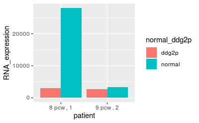

```r
long_table%>%filter(patient_num%in%c('1','2'))%>%group_by(patient)%>%ggplot(aes(patient,RNA_expression,fill=normal_ddg2p))+geom_bar(stat='identity',position = position_dodge())
```

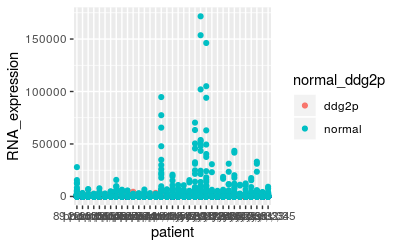

```r
long_table%>%group_by(normal_ddg2p)%>%ggplot(aes(patient,RNA_expression,col=normal_ddg2p))+
  geom_point()
```

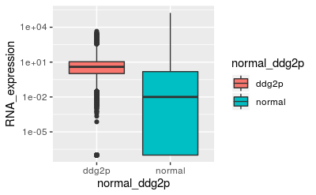

```r
long_table%>%mutate(RNA_expression=ifelse(RNA_expression==0,0.0000001,RNA_expression))%>%
ggplot(aes(normal_ddg2p,RNA_expression,fill=normal_ddg2p))+geom_boxplot()+scale_y_log10()
```

[figure not shown]

```r
long_table%>%mutate(RNA_expression=ifelse(RNA_expression==0,0.000001,RNA_expression))%>%
              ggplot(aes(normal_ddg2p,log10(RNA_expression),col=normal_ddg2p))+
  geom_violin()+facet_wrap(~age)
```

```r
long_table%>%filter(normal_ddg2p=='normal')%>%summarize(average=mean(RNA_expression))%>%pull(average)
```

```
[1] 7.289608
```

```r
long_table%>%filter(normal_ddg2p=='ddg2p')%>%summarize(average=mean(RNA_expression))%>%pull(average)
```

```
[1] 15.64407
```

```r
long_table%>%filter(normal_ddg2p=='normal')%>%summarize(max=max(RNA_expression))%>%pull(max)
```

```
[1] 171638.3
```

```r
long_table%>%filter(normal_ddg2p=='ddg2p')%>%summarize(max=max(RNA_expression))%>%pull(max)
```

```
[1] 4474.821
```

```r
sum(long_table$RNA_expression==0)
```

```
[1] 880636
```

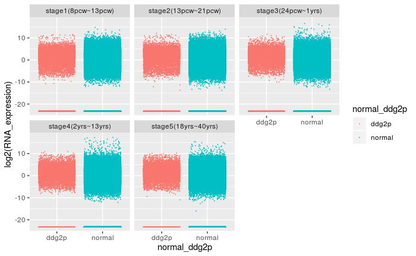

```r
long_table%>%mutate(RNA_expression=ifelse(RNA_expression==0,0.0000001,RNA_expression))%>%
              ggplot(aes(normal_ddg2p,log2(RNA_expression),col=normal_ddg2p))+
  geom_jitter(size=0.01)+facet_wrap(~human_group)
```

# 아래 두가지 그래프

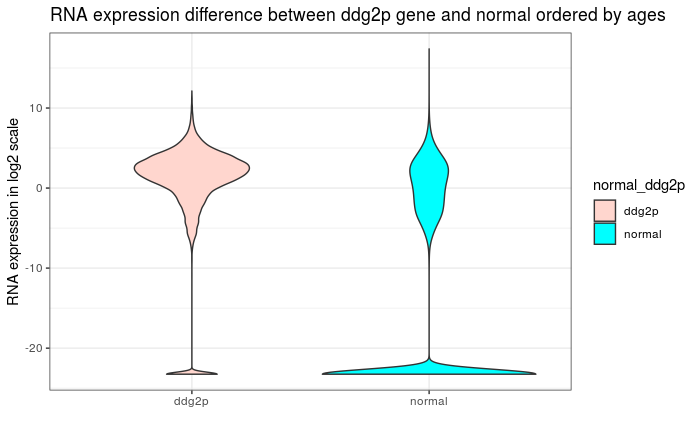

```r
long_table%>%mutate(RNA_expression=ifelse(RNA_expression==0,0.0000001,RNA_expression))%>%
              ggplot(aes(normal_ddg2p,log2(RNA_expression),fill=normal_ddg2p))+
  geom_violin()+scale_fill_hue(l=99, c=99)+
  #geom_jitter(col='yellow',size=0.005,alpha=0.007)+#facet_wrap(~human_group)+

  theme_bw()+
  theme(strip.background =element_rect(fill="pink"))+
  theme(strip.text = element_text(colour = 'white'))+
  labs(title = 'RNA expression difference between ddg2p gene and normal ordered by ages',x='',y='RNA expression in log2 scale')
```

```r
p<-long_table%>%mutate(RNA_expression=ifelse(RNA_expression==0,0.0000001,RNA_expression))%>%
              ggplot(aes(normal_ddg2p,log2(RNA_expression),fill=normal_ddg2p))+
  geom_boxplot()+scale_fill_hue(l=99, c=99)
```

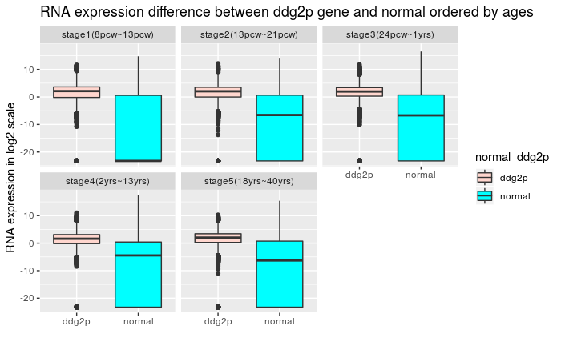

```r
 #+ geom_jitter(col='yellow',size=0.005,alpha=0.007)
p+facet_wrap(~human_group)+
  labs(title = 'RNA expression difference between ddg2p gene and normal ordered by ages',x='',y='RNA expression in log2 scale')
```

많은 코멘트가 그랬듯이 jitter로 나타내었던 형광이 너무 돋보인다는 의견이 많아서 없앴다. 사실 분포를 보여주기보다는 최대값은 normal에서 나오지만 평균 발현량은 ddg2p가 높다는것이 핵심이기 때문에 없애는게 맞는것 같다. 또한 제목을 normal을 써서 legend와 통일하였고 바이올린 플랏은 5개의 stage로 나누는 것이 의미가 없다고 판단되어 하나로 합쳤다(5개 모두 같은 양상을 띄므로) 하지만, Boxplot의 경우, stage1의 normal 유전자의 평균값이 0인것이 중요하다고 생각하기 때문에 그대로 두었다. 코멘트 2의 의견중에서 gene consequence로 나누는 것은 의미가 없다. 왜냐하면 애초에 DDg2p와 normal 유전자의 비교를 하는것이 목적이기 떄문에 나누면 내가 말하고자 하는 바와 상관없는 결과가 나오게 된다. 또한 표본이 적어서 바이올릿 플랏의 경우는 합쳤다.